# R_Project_3

Katrina Grigoreva

```r
#Insert your code here.
seq(2,20,by = 2)
```

```
##  [1]  2  4  6  8 10 12 14 16 18 20
```

### Note:

You will use ‘Admission_Predict.csv’ for Assignment-3. This dataset includes the data of the applicants of an academic program. Each application has a unique serial number, which represents a particular student. The dataset contains several parameters which are considered important during the application for Masters Programs. The parameters included are :

1. GRE Scores (out of 340)
2. TOEFL Scores (out of 120)
3. University Rating (out of 5)
4. Statement of Purpose (SOP) (out of 5)
5. Letter of Recommendation (LOR) Strength (out of 5)
6. Undergraduate GPA (out of 10)
7. Research Experience (either 0 or 1)
8. Chance of Admit (ranging from 0 to 1)

**Download “Admission_Predict.csv” dataset and load it as ‘data’.**

```r
admission <- read.csv('Admission_Predict.csv')
#View(admission)
```

## Question 1 (30 points in total)

1. i- Display the first three rows in this dataset.(1 point)

```r
head(admission, 3)
```

```
##   Serial.No. GRE.Score TOEFL.Score University.Rating SOP LOR CGPA Research
## 1          1       337         118                 4 4.5 4.5 9.65        1
## 2          2       324         107                 4 4.0 4.5 8.87        1
## 3          3       316         104                 3 3.0 3.5 8.00        1
##   Chance.of.Admit
## 1            0.92
## 2            0.76
## 3            0.72
```

ii - Display the structure of all variables.(1 point)

```r
str(admission)
```

```
## 'data.frame':    400 obs. of  9 variables:
##  $ Serial.No.       : int  1 2 3 4 5 6 7 8 9 10 ...
##  $ GRE.Score        : int  337 324 316 322 314 330 321 308 302 323 ...
##  $ TOEFL.Score      : int  118 107 104 110 103 115 109 101 102 108 ...
##  $ University.Rating: int  4 4 3 3 2 5 3 2 1 3 ...
##  $ SOP              : num  4.5 4 3 3.5 2 4.5 3 3 2 3.5 ...
##  $ LOR              : num  4.5 4.5 3.5 2.5 3 3 4 4 1.5 3 ...
##  $ CGPA             : num  9.65 8.87 8 8.67 8.21 9.34 8.2 7.9 8 8.6 ...
##  $ Research         : int  1 1 1 1 0 1 1 0 0 0 ...
##  $ Chance.of.Admit  : num  0.92 0.76 0.72 0.8 0.65 0.9 0.75 0.68 0.5 0.45 ...
```

iii - Print the descriptive statistics of the admission data to understand the data a little better (min, max, mean, median, 1st and 3rd quartiles). (1 point)

```r
summary(admission)
```

```
##    Serial.No.      GRE.Score      TOEFL.Score    University.Rating
##  Min.   :  1.0   Min.   :290.0   Min.   : 92.0   Min.   :1.000
##  1st Qu.:100.8   1st Qu.:308.0   1st Qu.:103.0   1st Qu.:2.000
##  Median :200.5   Median :317.0   Median :107.0   Median :3.000
##  Mean   :200.5   Mean   :316.8   Mean   :107.4   Mean   :3.087
##  3rd Qu.:300.2   3rd Qu.:325.0   3rd Qu.:112.0   3rd Qu.:4.000
##  Max.   :400.0   Max.   :340.0   Max.   :120.0   Max.   :5.000
##       SOP           LOR             CGPA          Research
##  Min.   :1.0   Min.   :1.000   Min.   :6.800   Min.   :0.0000
##  1st Qu.:2.5   1st Qu.:3.000   1st Qu.:8.170   1st Qu.:0.0000
##  Median :3.5   Median :3.500   Median :8.610   Median :1.0000
##  Mean   :3.4   Mean   :3.453   Mean   :8.599   Mean   :0.5475
##  3rd Qu.:4.0   3rd Qu.:4.000   3rd Qu.:9.062   3rd Qu.:1.0000
##  Max.   :5.0   Max.   :5.000   Max.   :9.920   Max.   :1.0000
##  Chance.of.Admit
##  Min.   :0.3400
##  1st Qu.:0.6400
##  Median :0.7300
##  Mean   :0.7244
##  3rd Qu.:0.8300
##  Max.   :0.9700
```

iv - Use a histogram to assess the normality of the ‘Chance.of.Admit’ variable and explain whether it appears normally distributed or not and why? (1 point)

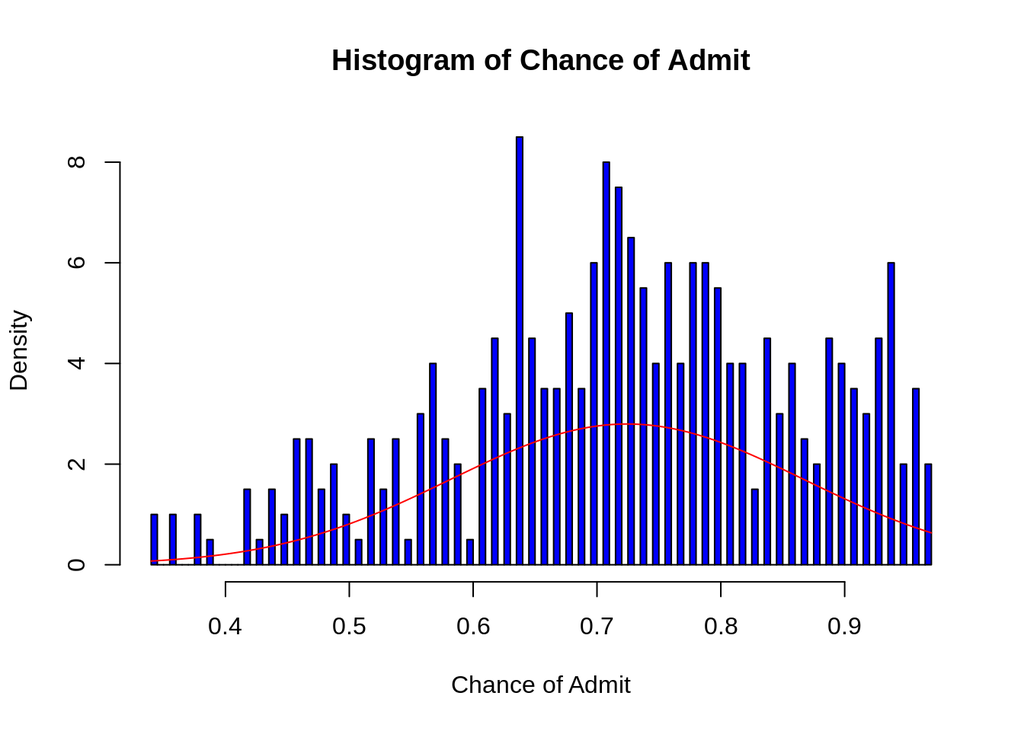

```r
hist(admission$Chance.of.Admit, freq=F, breaks=100, col="blue", xlab="Chance of Admit", main="Histogram of Chance of Admit")

curve(dnorm(x, mean=mean(admission$Chance.of.Admit), sd=sd(admission$Chance.of.Admit)), add=TRUE, col="red")
```

```r
#Chance.of.Admit variable is not normally (symmetrically) distributed. The histogram and the curve has a left-skewed distribution.
```

2. Create a set of boxplots that shows the distribution of Chance.of.Admit and SOP variables.Use different colors for different SOP scores month. (8 points)

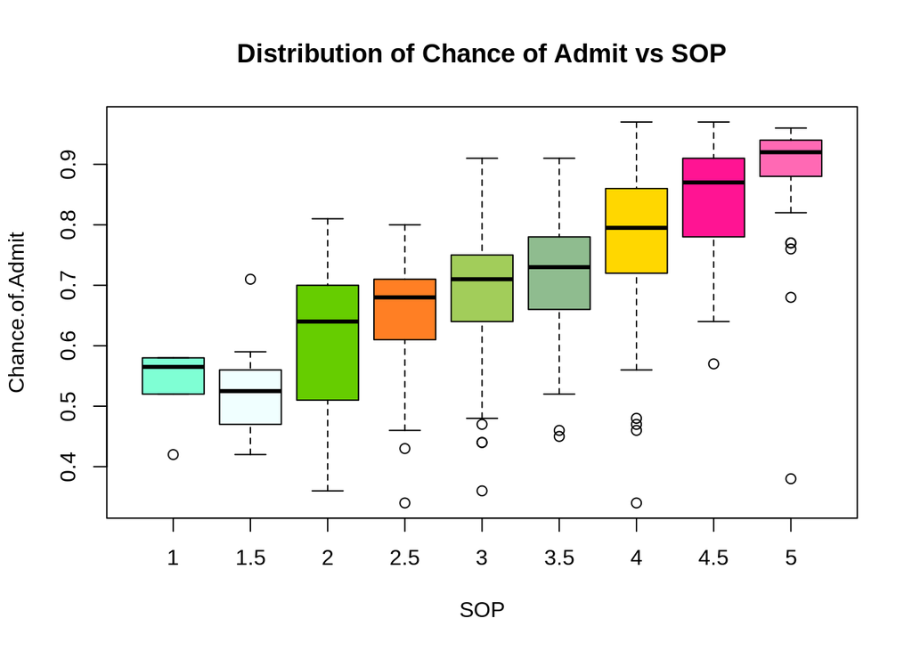

```r
boxplot(admission$Chance.of.Admit ~ admission$SOP,
        col = c("aquamarine", "azure", "chartreuse3", "chocolate1", "darkolivegreen3", "darkseagreen", "gold", "deeppink", "hotpink"),
        xlab = "SOP", ylab = "Chance.of.Admit",
        main = "Distribution of Chance of Admit vs SOP")
```

i- Find the covariance between the “GRE.Score” and the “Chance.of.Admit”. (3 points)

```r
cov(admission$GRE.Score, admission$Chance.of.Admit)
```

```
## [1] 1.313271
```

```r
#Output: 1.313271
```

ii- Find the correlation between the “GRE.Score”, “TOEFL.Score”, “CGPA” and the “Chance.of.Admit”. (3 points)

```r
library(dplyr)
cor(select(admission, GRE.Score, TOEFL.Score, CGPA, Chance.of.Admit))
```

```
##                 GRE.Score TOEFL.Score      CGPA Chance.of.Admit
## GRE.Score       1.0000000   0.8359768 0.8330605       0.8026105
## TOEFL.Score     0.8359768   1.0000000 0.8284174       0.7915940
## CGPA            0.8330605   0.8284174 1.0000000       0.8732891
## Chance.of.Admit 0.8026105   0.7915940 0.8732891       1.0000000
```

iii - Interpret the covariance and correlation results obtained from i and ii in terms of the strength and direction of the relationship. (4 points)

```r
#Correlation of Chance.of.Admit vs GRE.Score = 0.8026105
#Correlation of Chance.of.Admit vs TOEFL.Score = 0.7915940
#Correlation of Chance.of.Admit vs CGPA = 0.8732891

#Chance.of.Admit and all 3 variables (GRE.Score, TOEFL.Score, and CGPA) has a strong positive correlation, close to 1. Out of 3 variables, CGPA has the strongest correlation with Chance.of.Admit.

#The positive correlation means that when one variable changes in one direction, the other variable changes in the same direction.
```

4. Use ggplot() to plot the graphs to see the relationship between each of three variables (GRE.Score, TOEFL.Score, CGPA) with Chance.of.Admit. (8 points)

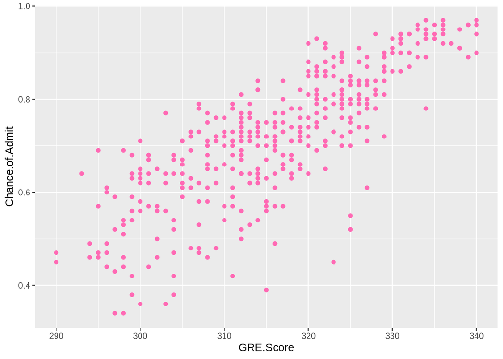

```r
library(ggplot2)

ggplot(data = admission, mapping = aes(x = GRE.Score, y = Chance.of.Admit)) +
  geom_point(alpha = 1, col = "hotpink")
```

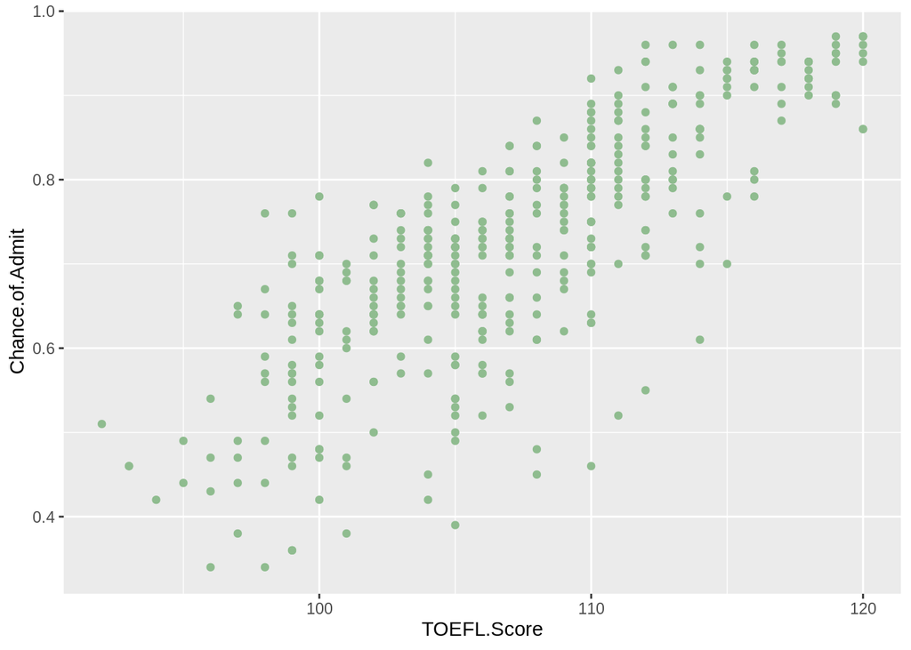

```r
ggplot(data = admission, mapping = aes(x = TOEFL.Score, y = Chance.of.Admit)) +
  geom_point(alpha = 1, col = "darkseagreen")
```

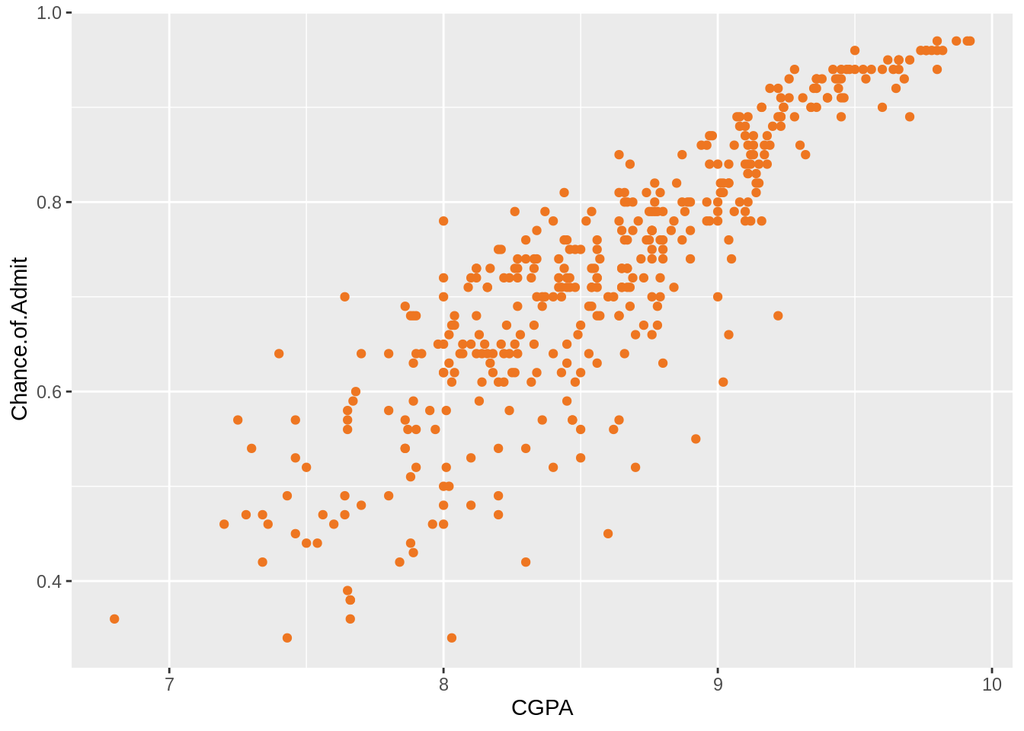

```r
ggplot(data = admission, mapping = aes(x = CGPA, y = Chance.of.Admit)) +
  geom_point(alpha = 1, col = "chocolate2")
```